# **Objective of the Instacart Dataset**

The Instacart dataset helps us understand how customers shop for groceries online. It contains details about users' past orders, including which products they bought, when they ordered, and whether they reordered the same items. The main goal is to predict which products a user is likely to buy again in their next order. This can help improve product recommendations and personalize the shopping experience.

# **Instacart Data**

Each row in the table represents a product purchased in a specific order.

Here’s what the key columns mean:

**department / aisle:** Tells where the product belongs in the store (e.g., frozen, meat).

**product_id / product_name:** Identifies the product (e.g., Ground Turkey Chub).

**order_id:** Unique ID for each order.

**add_to_cart_order:** Position of the item in the user’s cart (e.g., 1st item, 2nd item, etc.).

**reordered:**

1 = the user has bought it before

0 = it’s their first time buying it.

**user_id:** Identifies the customer who placed the order.

**eval_set:** Type of dataset (train, test, or prior) for model building.

**order_number:** Which number order it is for the user.

**order_dow:** Day of the week the order was placed (0 = Sunday, 6 = Saturday).

**order_hour_of_day:** Hour the order was placed (e.g., 18 = 6 PM).

**days_since_prior_order:** Days since the customer’s last order.

```python
import pandas as pd
import numpy as np
import matplotlib.pyplot as plt
import seaborn as sns
```

```python
import pandas as pd

# Specify the correct path to your CSV file
csv_file_path ="/Users/paritapatel/Documents/SEM 3/MARKETING ANALYTICS/PROJECT/final.csv"

# Read the CSV file
data = pd.read_csv(csv_file_path, encoding="ISO-8859-1")
```

```python
data.info
```

```
<bound method DataFrame.info of          department_id  department  aisle_id                aisle  product_id  \
0                    1      frozen        34  frozen meat seafood         118
1                    1      frozen        34  frozen meat seafood         118
2                    1      frozen        34  frozen meat seafood         118
3                    1      frozen        34  frozen meat seafood         118
4                    1      frozen        34  frozen meat seafood         118
...                ...         ...       ...                  ...         ...
1048570             16  dairy eggs        86                 eggs        5115
1048571             16  dairy eggs        86                 eggs        5115
1048572             16  dairy eggs        86                 eggs        5115
1048573             16  dairy eggs        86                 eggs        5115
1048574             16  dairy eggs        86                 eggs        5115

                      product_name  order_id  add_to_cart_order  reordered  \
0               Ground Turkey Chub    110900                 29          1
```

[output cut: 38 more lines]

```python
data.columns
```

```
Index(['department_id', 'department', 'aisle_id', 'aisle', 'product_id',
       'product_name', 'order_id', 'add_to_cart_order', 'reordered', 'user_id',
       'eval_set', 'order_number', 'order_dow', 'order_hour_of_day',
       'days_since_prior_order'],
      dtype='object')
```

```python
data.head()
```

|  | department_id | department | aisle_id | aisle | product_id | product_name | order_id | add_to_cart_order | reordered | user_id | eval_set | order_number | order_dow | order_hour_of_day | days_since_prior_order |
| --- | --- | --- | --- | --- | --- | --- | --- | --- | --- | --- | --- | --- | --- | --- | --- |
| 0 | 1 | frozen | 34 | frozen meat seafood | 118 | Ground Turkey Chub | 110900 | 29 | 1 | 119781 | train | 19 | 4 | 9 | 8 |
| 1 | 1 | frozen | 34 | frozen meat seafood | 118 | Ground Turkey Chub | 539714 | 2 | 0 | 58783 | train | 17 | 0 | 18 | 30 |
| 2 | 1 | frozen | 34 | frozen meat seafood | 118 | Ground Turkey Chub | 1009730 | 2 | 1 | 16301 | train | 21 | 4 | 12 | 6 |
| 3 | 1 | frozen | 34 | frozen meat seafood | 118 | Ground Turkey Chub | 1593147 | 11 | 1 | 22716 | train | 10 | 0 | 10 | 8 |
| 4 | 1 | frozen | 34 | frozen meat seafood | 118 | Ground Turkey Chub | 1667476 | 32 | 0 | 123212 | train | 22 | 4 | 21 | 7 |

### Data Cleaning

```python
#check for null values in our data
print("Missing values:\n", data.isnull().sum())
```

```
Missing values:
 department_id             0
department                0
aisle_id                  0
aisle                     0
product_id                0
product_name              0
order_id                  0
add_to_cart_order         0
reordered                 0
user_id                   0
eval_set                  0
order_number              0
order_dow                 0
order_hour_of_day         0
days_since_prior_order    0
dtype: int64
```

```python
#Fill missing days_since_prior_order with 0
data['days_since_prior_order'].fillna(0, inplace=True)
```

```python
data['days_since_prior_order']
```

```
0           8
1          30
2           6
3           8
4           7
           ..
1048570     9
1048571    15
1048572     6
1048573    15
1048574    12
Name: days_since_prior_order, Length: 1048575, dtype: int64
```

```python
# Drop duplicates if any
data.drop_duplicates(inplace=True)
```

```python
#Verify cleaning
print("\nData shape after cleaning:", data.shape)
print("\nSample data:\n", data.head())
```

```
Data shape after cleaning: (1048575, 15)

Sample data:
    department_id department  aisle_id                aisle  product_id  \
0              1     frozen        34  frozen meat seafood         118
1              1     frozen        34  frozen meat seafood         118
2              1     frozen        34  frozen meat seafood         118
3              1     frozen        34  frozen meat seafood         118
4              1     frozen        34  frozen meat seafood         118

         product_name  order_id  add_to_cart_order  reordered  user_id  \
0  Ground Turkey Chub    110900                 29          1   119781
1  Ground Turkey Chub    539714                  2          0    58783
2  Ground Turkey Chub   1009730                  2          1    16301
3  Ground Turkey Chub   1593147                 11          1    22716
4  Ground Turkey Chub   1667476                 32          0   123212

  eval_set  order_number  order_dow  order_hour_of_day  days_since_prior_order
0    train            19          4                  9                       8
1    train            17          0                 18                      30
2    train            21          4                 12                       6
3    train            10          0                 10                       8
4    train            22          4                 21                       7
```

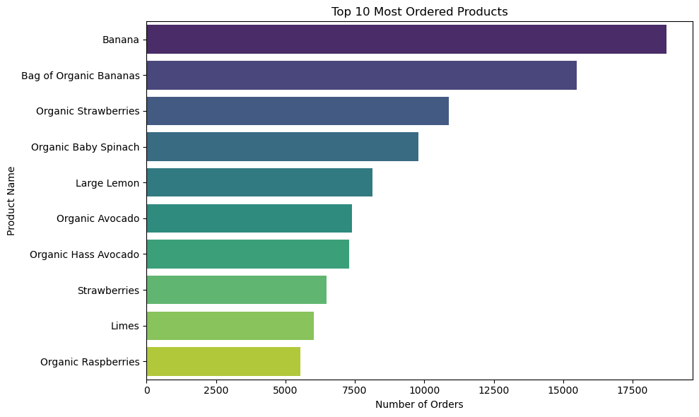

```python
top_products = data['product_name'].value_counts().head(10)

plt.figure(figsize=(10,6))
sns.barplot(y=top_products.index, x=top_products.values, palette='viridis')
plt.title('Top 10 Most Ordered Products')
plt.xlabel('Number of Orders')
plt.ylabel('Product Name')
plt.tight_layout()
plt.show()
```

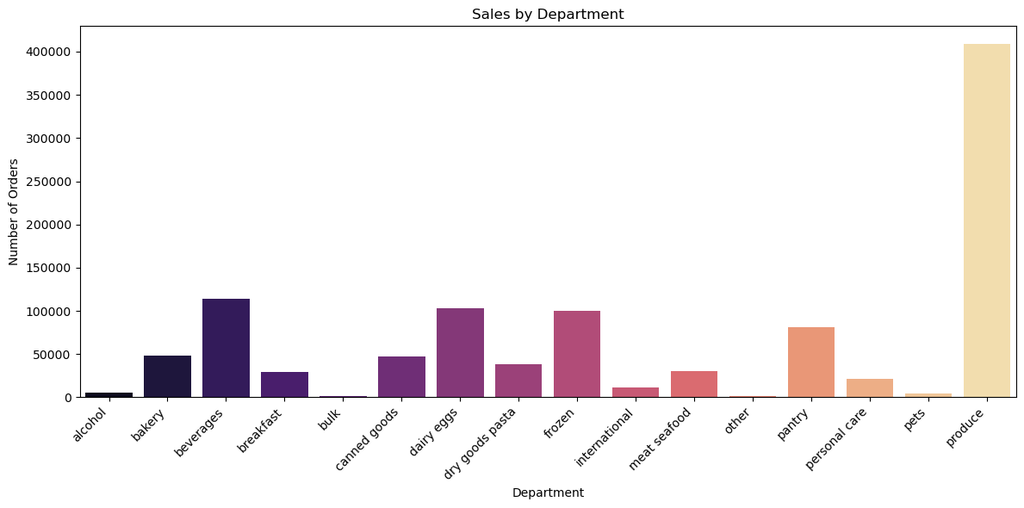

```python
sales_by_department = data.groupby('department')['order_id'].count().reset_index()  # Replace 'order_id' with the column representing sales

plt.figure(figsize=(12, 6))
sns.barplot(x='department', y='order_id', data=sales_by_department, palette='magma') # Replace 'order_id'
plt.title('Sales by Department')
plt.xlabel('Department')
plt.ylabel('Number of Orders') # Or 'Total Sales'
plt.xticks(rotation=45, ha='right') # Rotate x-axis labels for better readability
plt.tight_layout()
plt.show()
```

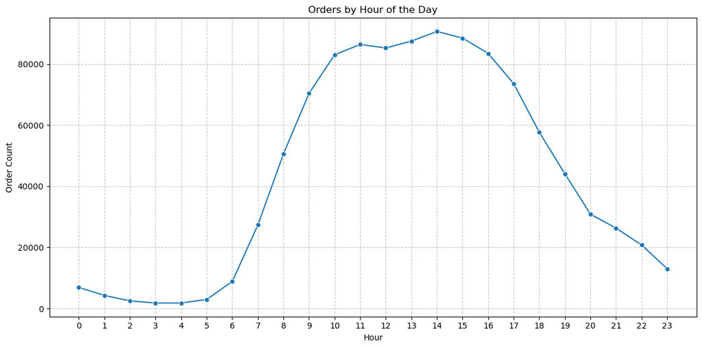

```python
# Calculate order counts for each hour
order_counts = data['order_hour_of_day'].value_counts().sort_index()

# Orders by Hour of Day - Different Graph (using a line plot)
plt.figure(figsize=(12, 6))
sns.lineplot(x=order_counts.index, y=order_counts.values, marker='o')
plt.title("Orders by Hour of the Day")
plt.xlabel("Hour")
plt.ylabel("Order Count")
plt.xticks(range(24))
plt.grid(True, linestyle='--', alpha=0.7)
plt.tight_layout()
plt.show()
```

#### creation of churn label

```python
# Pull latest order per user
last_orders = data.sort_values(['user_id', 'order_number'], ascending=[True, False]).drop_duplicates('user_id')

# Check max & distribution of days_since_prior_order
print("Max days_since_prior_order:", last_orders['days_since_prior_order'].max())
print("\nDistribution:\n", last_orders['days_since_prior_order'].value_counts().sort_index())
```

```
Max days_since_prior_order: 30

Distribution:
 0      2013
1      2619
2      3392
3      3913
4      4513
5      4933
6      6117
7      9009
8      5297
9      3794
10     3143
11     2880
```

[output cut: 20 more lines]

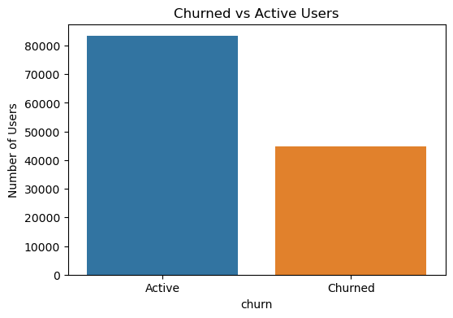

```
Churn rate: 34.99%
```

```python
import pandas as pd
import seaborn as sns
import matplotlib.pyplot as plt

# Step 2.1: Identify each user's last order
last_orders = data.sort_values(['user_id', 'order_number'], ascending=[True, False]).drop_duplicates('user_id')

# Step 2.2: Create churn label (1 = churned, 0 = active)
last_orders['churn'] = (last_orders['days_since_prior_order'] > 25).astype(int)

# Step 2.3: Prepare churn label dataframe
user_churn_df = last_orders[['user_id', 'days_since_prior_order', 'churn']].rename(columns={
    'days_since_prior_order': 'last_days_since_order'
})

# Step 2.4: Plot churn distribution
plt.figure(figsize=(6, 4))
sns.countplot(x='churn', data=user_churn_df)
plt.title("Churned vs Active Users")
plt.xticks([0, 1], ['Active', 'Churned'])
plt.ylabel("Number of Users")
plt.show()

# Step 2.5: Print churn rate
churn_rate = user_churn_df['churn'].mean()
print(f"Churn rate: {churn_rate:.2%}")
```

### Exploratory Data Analyis

##### Create User-Level Features

```python
# Aggregate key user-level metrics
user_agg = data.groupby('user_id').agg({
    'order_number': 'max',
    'days_since_prior_order': 'mean',
    'reordered': 'mean',
    'add_to_cart_order': 'mean',
    'order_hour_of_day': lambda x: x.mode()[0],
    'order_dow': lambda x: x.mode()[0],
    'department': pd.Series.nunique
}).reset_index()

# Rename columns
user_agg.columns = [
    'user_id', 'total_orders', 'avg_days_between_orders', 'reorder_rate',
    'avg_cart_size', 'most_common_hour', 'most_common_dow', 'unique_departments'
]

# Merge with churn label
user_data = pd.merge(user_agg, user_churn_df, on='user_id')
```

#### Churn Impact by Feature

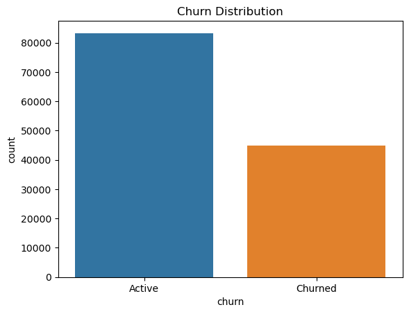

```python
sns.countplot(x='churn', data=user_data)
plt.title('Churn Distribution')
plt.xticks([0, 1], ['Active', 'Churned'])
plt.show()
```

#### KDE: Distributions by Churn

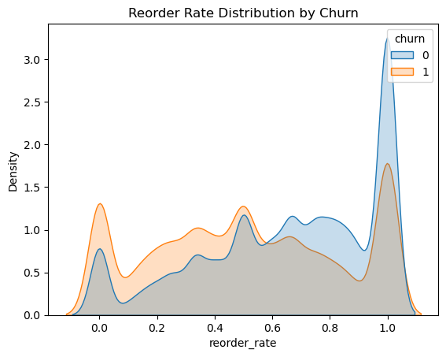

```python
sns.kdeplot(data=user_data, x='reorder_rate', hue='churn', fill=True, common_norm=False)
plt.title('Reorder Rate Distribution by Churn')
plt.show()
```

#### Total Orders

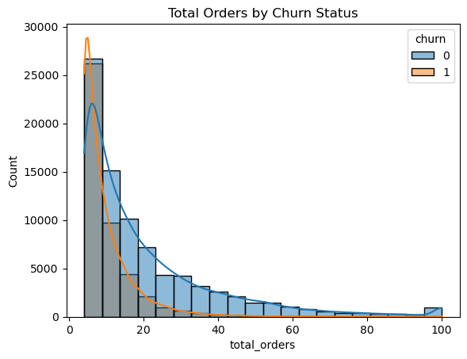

```python
sns.histplot(data=user_data, x='total_orders', hue='churn', kde=True, bins=20)
plt.title('Total Orders by Churn Status')
plt.show()
```

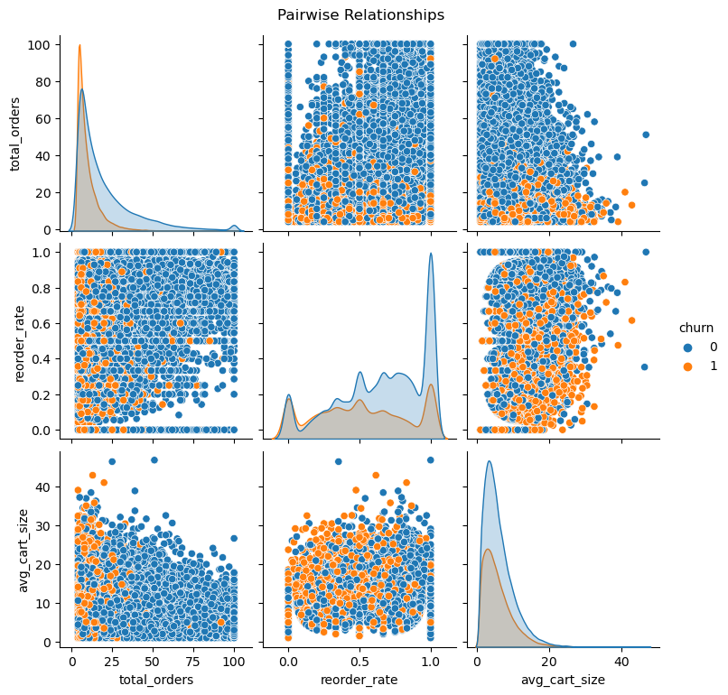

```python
sns.pairplot(user_data[['total_orders', 'reorder_rate', 'avg_cart_size', 'churn']], hue='churn')
plt.suptitle('Pairwise Relationships', y=1.02)
plt.show()
```

#### RFM Analysis

##### Recency: Days since last order (from the last order)

##### Frequency: Total number of orders

##### Monetary: Total spend per user

```python
user_data['recency'] = user_data['avg_days_between_orders']
user_data['frequency'] = user_data['total_orders']
user_data['monetary'] = user_data['total_orders'] * user_data['avg_cart_size']
```

#### RFM Segmetation

```python
# Define custom bins for Recency, Frequency, and Monetary
user_data['recency_score'] = pd.cut(user_data['recency'], bins=4, labels=[4, 3, 2, 1], include_lowest=True)
user_data['frequency_score'] = pd.cut(user_data['frequency'], bins=4, labels=[1, 2, 3, 4], include_lowest=True)
user_data['monetary_score'] = pd.cut(user_data['monetary'], bins=4, labels=[1, 2, 3, 4], include_lowest=True)

# Combine the RFM scores into a single score
user_data['RFM_Score'] = user_data['recency_score'].astype(str) + user_data['frequency_score'].astype(str) + user_data['monetary_score'].astype(str)

# Optionally, create RFM categories
user_data['RFM_Category'] = user_data['RFM_Score'].apply(lambda x:
                                                       'Best Customers' if x == '444' else
                                                       ('Loyal Customers' if x[0] == '4' else
                                                       ('At Risk' if x[1] == '1' else 'Others')))

# Step 3: Display the RFM scores and categories
print(user_data[['user_id', 'recency', 'frequency', 'monetary', 'RFM_Score', 'RFM_Category']].head())
```

```
   user_id  recency  frequency    monetary RFM_Score     RFM_Category
0        1     14.0         11   73.333333       311          At Risk
1        2     30.0         15  256.363636       111          At Risk
2        5      6.0          5   25.000000       411  Loyal Customers
3        7      6.0         21  102.375000       411  Loyal Customers
4        8     10.0          4   38.500000       311          At Risk
```

#### Distribution of RFM Scores

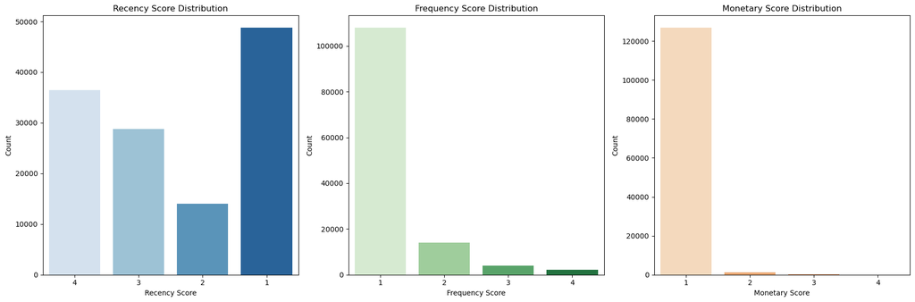

```python
# Plot the distribution of Recency, Frequency, and Monetary scores
plt.figure(figsize=(18, 6))

# Recency Score Distribution
plt.subplot(1, 3, 1)
sns.countplot(x=user_data['recency_score'], palette='Blues')
plt.title('Recency Score Distribution')
plt.xlabel('Recency Score')
plt.ylabel('Count')

# Frequency Score Distribution
plt.subplot(1, 3, 2)
sns.countplot(x=user_data['frequency_score'], palette='Greens')
plt.title('Frequency Score Distribution')
plt.xlabel('Frequency Score')
plt.ylabel('Count')

# Monetary Score Distribution
plt.subplot(1, 3, 3)
sns.countplot(x=user_data['monetary_score'], palette='Oranges')
plt.title('Monetary Score Distribution')
plt.xlabel('Monetary Score')
plt.ylabel('Count')

plt.tight_layout()
plt.show()
```

#### 3D Plot for RFM Scores

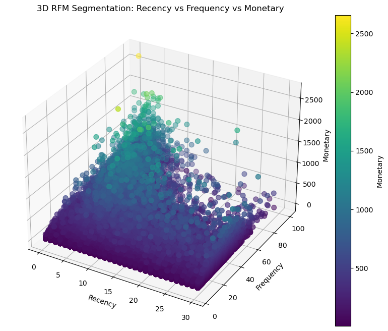

```python
from mpl_toolkits.mplot3d import Axes3D

# 3D Plot for Recency, Frequency, and Monetary
fig = plt.figure(figsize=(10, 8))
ax = fig.add_subplot(111, projection='3d')

# Create the 3D scatter plot
sc = ax.scatter(user_data['recency'], user_data['frequency'], user_data['monetary'], c=user_data['monetary'], cmap='viridis', s=50)

ax.set_xlabel('Recency')
ax.set_ylabel('Frequency')
ax.set_zlabel('Monetary')

plt.title('3D RFM Segmentation: Recency vs Frequency vs Monetary')
plt.colorbar(sc, label='Monetary')
plt.show()
```

#### Pre-processing Data

```python
import pandas as pd
import numpy as np
from sklearn.model_selection import train_test_split, StratifiedKFold, cross_val_score, GridSearchCV
from sklearn.preprocessing import StandardScaler, OneHotEncoder
from sklearn.compose import ColumnTransformer
from sklearn.pipeline import Pipeline
from sklearn.metrics import classification_report, confusion_matrix, roc_auc_score
from sklearn.ensemble import RandomForestClassifier
from sklearn.linear_model import LogisticRegression
from sklearn.tree import DecisionTreeClassifier
from sklearn.svm import SVC
import joblib
```

```python
correlation_matrix = user_data.corr(numeric_only=True)
churn_corr = correlation_matrix['churn'].sort_values(ascending=False)
print(churn_corr)
```

```
churn                      1.000000
avg_days_between_orders    0.871369
last_days_since_order      0.871369
recency                    0.871369
user_id                    0.004278
most_common_hour           0.004161
unique_departments        -0.008908
most_common_dow           -0.014530
avg_cart_size             -0.024792
reorder_rate              -0.216817
monetary                  -0.228980
total_orders              -0.299390
frequency                 -0.299390
Name: churn, dtype: float64
```

We can see that there is data lekage

Feature Correlation with churn

avg_days_between_orders,recency,last_days_since_order

```python
# Droping these three columns before modeling
leaky_features = ['avg_days_between_orders', 'last_days_since_order', 'recency']
X = user_data.drop(columns=['churn'] + leaky_features)
y = user_data['churn']
```

```python
numeric_features = [
    'frequency', 'monetary', 'total_orders',
    'reorder_rate', 'avg_cart_size',
    'most_common_hour', 'unique_departments', 'most_common_dow'
]
categorical_features = ['RFM_Category']
```

```python
from sklearn.model_selection import train_test_split

X = user_data.drop(columns=['churn'])
y = user_data['churn']

X_train, X_test, y_train, y_test = train_test_split(
    X, y, stratify=y, test_size=0.2, random_state=42)
```

```python
numeric_transformer = StandardScaler()
categorical_transformer = OneHotEncoder(handle_unknown='ignore')

preprocessor = ColumnTransformer(
    transformers=[
        ('num', numeric_transformer, numeric_features),
        ('cat', categorical_transformer, categorical_features)
    ])

pipeline = Pipeline([
    ('preprocessor', preprocessor),
    ('classifier', RandomForestClassifier(class_weight='balanced', random_state=42))
])
```

```python
from sklearn.metrics import ConfusionMatrixDisplay, RocCurveDisplay, roc_curve
from sklearn.linear_model import LogisticRegression
from sklearn.tree import DecisionTreeClassifier
from sklearn.ensemble import GradientBoostingClassifier
from sklearn.svm import SVC
from sklearn.naive_bayes import GaussianNB
from sklearn.pipeline import Pipeline
from sklearn.compose import ColumnTransformer
from sklearn.preprocessing import StandardScaler, OneHotEncoder
from sklearn.ensemble import RandomForestClassifier
from sklearn.model_selection import train_test_split
from sklearn.metrics import confusion_matrix, classification_report, roc_auc_score
```

```python
models = {
    'Random Forest': RandomForestClassifier(class_weight='balanced', random_state=42),
    'Logistic Regression': LogisticRegression(class_weight='balanced', max_iter=1000),
    'Decision Tree': DecisionTreeClassifier(class_weight='balanced', random_state=42),
    'Gradient Boosting': GradientBoostingClassifier(),

}
# Store results
model_results = {}

# Loop through models
for name, clf in models.items():
    pipeline = Pipeline([
        ('preprocessor', preprocessor),
        ('classifier', clf)
    ])
    pipeline.fit(X_train, y_train)
    y_pred = pipeline.predict(X_test)
    y_proba = pipeline.predict_proba(X_test)[:, 1]

    # Store all necessary outputs
    model_results[name] = {
        'confusion_matrix': confusion_matrix(y_test, y_pred),
        'classification_report': classification_report(y_test, y_pred, output_dict=True),
        'roc_auc': roc_auc_score(y_test, y_proba),
        'y_pred': y_pred,
        'y_proba': y_proba
    }

    print(f"=== {name} ===")
    print(confusion_matrix(y_test, y_pred))
    print(classification_report(y_test, y_pred))
    print("ROC-AUC:", roc_auc_score(y_test, y_proba))
    print("\n" + "-"*40 + "\n")
```

```
=== Random Forest ===
[[13109  3552]
 [ 3887  5080]]
              precision    recall  f1-score   support

           0       0.77      0.79      0.78     16661
           1       0.59      0.57      0.58      8967

    accuracy                           0.71     25628
   macro avg       0.68      0.68      0.68     25628
weighted avg       0.71      0.71      0.71     25628

ROC-AUC: 0.7964138318905309

----------------------------------------

=== Logistic Regression ===
[[9840 6821]
 [ 724 8243]]
              precision    recall  f1-score   support

           0       0.93      0.59      0.72     16661
           1       0.55      0.92      0.69      8967

    accuracy                           0.71     25628
   macro avg       0.74      0.75      0.70     25628
weighted avg       0.80      0.71      0.71     25628

ROC-AUC: 0.8155605592418652

----------------------------------------

=== Decision Tree ===
[[12548  4113]
 [ 4127  4840]]
              precision    recall  f1-score   support

           0       0.75      0.75      0.75     16661
           1       0.54      0.54      0.54      8967

```

[output cut: 8 more lines]

```
=== Gradient Boosting ===
[[12845  3816]
 [ 2954  6013]]
              precision    recall  f1-score   support

           0       0.81      0.77      0.79     16661
           1       0.61      0.67      0.64      8967

    accuracy                           0.74     25628
   macro avg       0.71      0.72      0.72     25628
weighted avg       0.74      0.74      0.74     25628

ROC-AUC: 0.8206639337334547

----------------------------------------
```

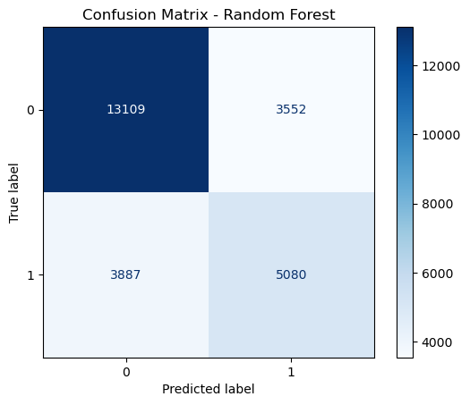

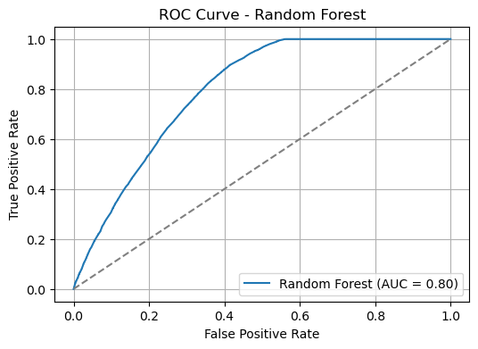

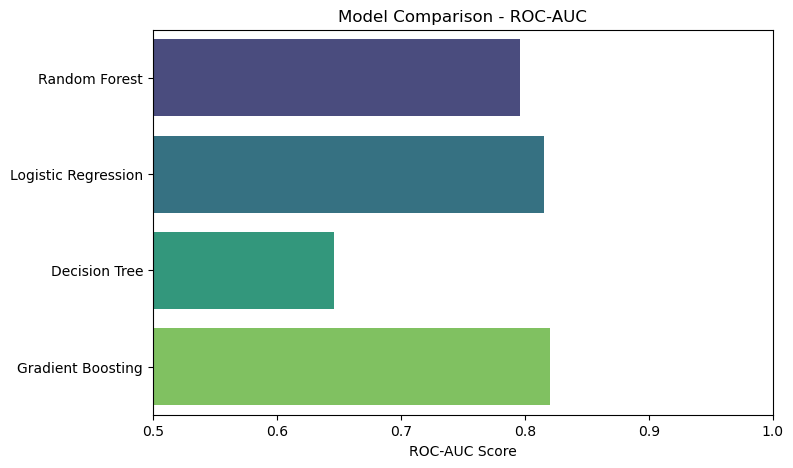

```python
# Confusion Matrix and ROC Curve for Random Forest
best_model = model_results['Random Forest']
y_pred_rf = best_model['y_pred']
y_proba_rf = best_model['y_proba']

# Confusion Matrix
disp = ConfusionMatrixDisplay(confusion_matrix(y_test, y_pred_rf))
disp.plot(cmap='Blues')
plt.title('Confusion Matrix - Random Forest')
plt.show()

# ROC Curve
fpr, tpr, _ = roc_curve(y_test, y_proba_rf)
plt.figure(figsize=(6, 4))
plt.plot(fpr, tpr, label=f"Random Forest (AUC = {roc_auc_score(y_test, y_proba_rf):.2f})")
plt.plot([0, 1], [0, 1], linestyle='--', color='gray')
plt.xlabel("False Positive Rate")
plt.ylabel("True Positive Rate")
plt.title("ROC Curve - Random Forest")
plt.legend()
plt.grid()
plt.show()

# Model comparison plot
plt.figure(figsize=(8, 5))
model_names = list(model_results.keys())
roc_aucs = [model_results[name]['roc_auc'] for name in model_names]
sns.barplot(x=roc_aucs, y=model_names, palette='viridis')
plt.xlabel('ROC-AUC Score')
plt.title('Model Comparison - ROC-AUC')
plt.xlim(0.5, 1.0)
plt.show()
```